# R Notebook

# Background project

Using devices such as Jawbone Up, Nike FuelBand, and Fitbit it is now possible to collect a large amount of data about personal activity relatively inexpensively. These type of devices are part of the quantified self movement - a group of enthusiasts who take measurements about themselves regularly to improve their health, to find patterns in their behavior, or because they are tech geeks. One thing that people regularly do is quantify how much of a particular activity they do, but they rarely quantify how well they do it.

In this project, your goal will be to use data from accelerometers on the belt, forearm, arm, and dumbell of 6 participants. They were asked to perform barbell lifts correctly and incorrectly in 5 different ways. More information is available from the website here: http://groupware.les.inf.puc-rio.br/har (see the section on the Weight Lifting Exercise Dataset).

# Background dataset

In this work (see the paper) we first define quality of execution and investigate three aspects that pertain to qualitative activity recognition: the problem of specifying correct execution, the automatic and robust detection of execution mistakes, and how to provide feedback on the quality of execution to the user. We tried out an on-body sensing approach (dataset here), but also an “ambient sensing approach” (by using Microsoft Kinect - dataset still unavailable)

Six young health participants were asked to perform one set of 10 repetitions of the Unilateral Dumbbell Biceps Curl in five different fashions: exactly according to the specification (Class A), throwing the elbows to the front (Class B), lifting the dumbbell only halfway (Class C), lowering the dumbbell only halfway (Class D) and throwing the hips to the front (Class E).

Class A corresponds to the specified execution of the exercise, while the other 4 classes correspond to common mistakes. Participants were supervised by an experienced weight lifter to make sure the execution complied to the manner they were supposed to simulate. The exercises were performed by six male participants aged between 20-28 years, with little weight lifting experience. We made sure that all participants could easily simulate the mistakes in a safe and controlled manner by using a relatively light dumbbell (1.25kg).

Read more: http://groupware.les.inf.puc-rio.br/har#weight_lifting_exercises#ixzz4ZypHm95A

# Data preparation

## Load libraries

```r
library(caret); library(rattle); library(rpart); library(rpart.plot)
library(randomForest);
```

## Import data

```r
# import the data from the URLs
training <- read.csv("https://d396qusza40orc.cloudfront.net/predmachlearn/pml-training.csv",na.strings = c("NA", ""))
testing <- read.csv("https://d396qusza40orc.cloudfront.net/predmachlearn/pml-testing.csv",na.strings = c("NA", ""))
```

## Data cleaning

```r
training <- training[, colSums(is.na(training)) == 0]
testing <- testing[, colSums(is.na(testing)) == 0]
```

## Explorative analysis of data

```r
dimtrain <- dim(training)
dimtest <- dim(testing)
head(training,5)
```

|  | X | user_name | raw_timestamp_part_1 | raw_timestamp_part_2 | cvtd_timestamp | new_window | num_window | roll_belt | pitch_belt | yaw_belt | total_accel_belt | gyros_belt_x | gyros_belt_y | gyros_belt_z | accel_belt_x | accel_belt_y | accel_belt_z | magnet_belt_x | magnet_belt_y | magnet_belt_z | roll_arm | pitch_arm | yaw_arm | total_accel_arm | gyros_arm_x | gyros_arm_y | gyros_arm_z | accel_arm_x | accel_arm_y | … |
| --- | --- | --- | --- | --- | --- | --- | --- | --- | --- | --- | --- | --- | --- | --- | --- | --- | --- | --- | --- | --- | --- | --- | --- | --- | --- | --- | --- | --- | --- | --- |
| 1 | 1 | carlitos | 1323084231 | 788290 | 05/12/2011 11:23 | no | 11 | 1.41 | 8.07 | -94.4 | 3 | 0.00 | 0.00 | -0.02 | -21 | 4 | 22 | -3 | 599 | -313 | -128 | 22.5 | -161 | 34 | 0.00 | 0.00 | -0.02 | -288 | 109 | … |
| 2 | 2 | carlitos | 1323084231 | 808298 | 05/12/2011 11:23 | no | 11 | 1.41 | 8.07 | -94.4 | 3 | 0.02 | 0.00 | -0.02 | -22 | 4 | 22 | -7 | 608 | -311 | -128 | 22.5 | -161 | 34 | 0.02 | -0.02 | -0.02 | -290 | 110 | … |
| 3 | 3 | carlitos | 1323084231 | 820366 | 05/12/2011 11:23 | no | 11 | 1.42 | 8.07 | -94.4 | 3 | 0.00 | 0.00 | -0.02 | -20 | 5 | 23 | -2 | 600 | -305 | -128 | 22.5 | -161 | 34 | 0.02 | -0.02 | -0.02 | -289 | 110 | … |
| 4 | 4 | carlitos | 1323084232 | 120339 | 05/12/2011 11:23 | no | 12 | 1.48 | 8.05 | -94.4 | 3 | 0.02 | 0.00 | -0.03 | -22 | 3 | 21 | -6 | 604 | -310 | -128 | 22.1 | -161 | 34 | 0.02 | -0.03 | 0.02 | -289 | 111 | … |
| 5 | 5 | carlitos | 1323084232 | 196328 | 05/12/2011 11:23 | no | 12 | 1.48 | 8.07 | -94.4 | 3 | 0.02 | 0.02 | -0.02 | -21 | 2 | 24 | -6 | 600 | -302 | -128 | 22.1 | -161 | 34 | 0.00 | -0.03 | 0.00 | -289 | 111 | … |

```r
inf <- summary(training$classe)
```

The dataset contains 60 different variables. The training set containts 19622 occurances and the test set 20. You can see that in the last column the ground-truth knowledge of the classe is located. The classe is divided in 5 different instances: A,B,C,D,E, which respetively occures 5580, 3797, 3422, 3216, 3607 times. The first 7 variables does not have predictive influence for the classe since they contain time stamps and range knowledge.

## Data cleaning

```r
training <- training[, colSums(is.na(training)) == 0]
testing <- testing[, colSums(is.na(testing)) == 0]
```

2. remove the 7 first columns without any predictive value

```r
trainData <- training[, -c(1:7)]
testData <- testing[, -c(1:7)]
```

## Data division

In order to get out-of-sample errors, we split the cleaned training set trainData into a training set (train, 70%) for prediction and a validation set (valid 30%) to compute the out-of-sample errors.

```r
set.seed(0128)
inTrain <- createDataPartition(trainData$classe, p = 0.7, list = FALSE)
train <- trainData[inTrain, ]
valid <- trainData[-inTrain, ]
```

# Make predictions :)

```r
control <- trainControl(method = "cv", number = 5)
fit_rpart <- train(classe ~ ., data = train, method = "rpart",
                   trControl = control)
print(fit_rpart, digits = 4)
```

```
CART

13737 samples
   52 predictor
    5 classes: 'A', 'B', 'C', 'D', 'E'

No pre-processing
Resampling: Cross-Validated (5 fold)
Summary of sample sizes: 10990, 10990, 10990, 10990, 10988
Resampling results across tuning parameters:

  cp       Accuracy  Kappa
  0.03611  0.5016    0.3492
  0.05934  0.4124    0.2040
  0.11301  0.3649    0.1230

Accuracy was used to select the optimal model using  the largest value.
The final value used for the model was cp = 0.03611.
```

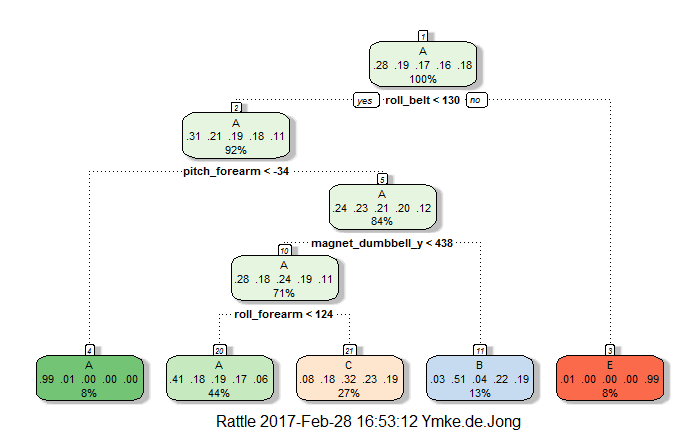

```r
fancyRpartPlot(fit_rpart$finalModel)
```

```r
# predict outcomes using validation set
predict_rpart <- predict(fit_rpart, valid)
# Show prediction result
(conf_rpart <- confusionMatrix(valid$classe, predict_rpart))
```

```
Confusion Matrix and Statistics

          Reference
Prediction    A    B    C    D    E
         A 1523   30  117    0    4
         B  476  388  275    0    0
         C  457   30  539    0    0
         D  439  172  353    0    0
         E  170  151  251    0  510

Overall Statistics

               Accuracy : 0.503
                 95% CI : (0.4901, 0.5158)
    No Information Rate : 0.5208
    P-Value [Acc > NIR] : 0.997

                  Kappa : 0.3503
 Mcnemar's Test P-Value : NA

Statistics by Class:

                     Class: A Class: B Class: C Class: D Class: E
Sensitivity            0.4969  0.50324  0.35114       NA  0.99222
Specificity            0.9465  0.85315  0.88805   0.8362  0.89350
Pos Pred Value         0.9098  0.34065  0.52534       NA  0.47135
Neg Pred Value         0.6338  0.91930  0.79502       NA  0.99917
Prevalence             0.5208  0.13101  0.26083   0.0000  0.08734
Detection Rate         0.2588  0.06593  0.09159   0.0000  0.08666
Detection Prevalence   0.2845  0.19354  0.17434   0.1638  0.18386
Balanced Accuracy      0.7217  0.67820  0.61959       NA  0.94286
```

```r
(accuracy_rpart <- conf_rpart$overall[1])
```

```
 Accuracy
0.5029737
```

## Random forest

Since classification tree method does not perform well, we try random forest method instead.

```r
fit_rf <- train(classe ~ ., data = train, method = "rf",
                   trControl = control)
print(fit_rf, digits = 4)
```

```
Random Forest

13737 samples
   52 predictor
    5 classes: 'A', 'B', 'C', 'D', 'E'

No pre-processing
Resampling: Cross-Validated (5 fold)
Summary of sample sizes: 10990, 10989, 10990, 10990, 10989
Resampling results across tuning parameters:

  mtry  Accuracy  Kappa
   2    0.9896    0.9868
  27    0.9900    0.9874
  52    0.9820    0.9773

Accuracy was used to select the optimal model using  the largest value.
The final value used for the model was mtry = 27.
```

```r
# predict outcomes using validation set
predict_rf <- predict(fit_rf, valid)
# Show prediction result
(conf_rf <- confusionMatrix(valid$classe, predict_rf))
```

```
Confusion Matrix and Statistics

          Reference
Prediction    A    B    C    D    E
         A 1669    3    1    0    1
         B   15 1117    6    1    0
         C    0    5 1019    2    0
         D    0    0   16  948    0
         E    0    0    0    2 1080

Overall Statistics

               Accuracy : 0.9912
                 95% CI : (0.9884, 0.9934)
    No Information Rate : 0.2862
    P-Value [Acc > NIR] : < 2.2e-16

                  Kappa : 0.9888
 Mcnemar's Test P-Value : NA

Statistics by Class:

                     Class: A Class: B Class: C Class: D Class: E
Sensitivity            0.9911   0.9929   0.9779   0.9948   0.9991
Specificity            0.9988   0.9954   0.9986   0.9968   0.9996
Pos Pred Value         0.9970   0.9807   0.9932   0.9834   0.9982
Neg Pred Value         0.9964   0.9983   0.9953   0.9990   0.9998
Prevalence             0.2862   0.1912   0.1771   0.1619   0.1837
Detection Rate         0.2836   0.1898   0.1732   0.1611   0.1835
Detection Prevalence   0.2845   0.1935   0.1743   0.1638   0.1839
Balanced Accuracy      0.9950   0.9941   0.9882   0.9958   0.9993
```

```r
(accuracy_rf <- conf_rf$overall[1])
```

```
Accuracy
0.991164
```

## Test the found model

We now use random forests to predict the outcome variable classe for the testing set.

```r
(predict(fit_rf, testData))
```

```
 [1] B A B A A E D B A A B C B A E E A B B B
Levels: A B C D E
```